# Análise Ambiental

Indicadores Ambientais Aplicados  
à Análise Ambiental

Luiz Diego Vidal Santos

## Visão Geral da Aula

### Tópicos

- 1 Indicadores físicos
- 2 Indicadores químicos
- 3 Indicadores biológicos
- 4 Indicadores hidrológicos
- 5 Indicadores geomorfológicos
- 6 Indicadores de uso da terra
- 7 Critérios de seleção
- 8 Indicadores simples e compostos
- 9 Diagnóstico e monitoramento

**Objetivo da Aula**

Selecionar e aplicar indicadores ambientais consistentes para o diagnóstico e o monitoramento, distinguindo indicadores simples de índices compostos.

# 1 - TIPOS DE INDICADORES

## Conceito e tipologia

### O que é um indicador

- Variável selecionada que **representa** um aspecto do sistema ambiental e permite comunicar tendência, condição ou efeito de gestão.
- Bom indicador (OECD, 2003):
  - **Relevância** - conecta-se a uma questão ambiental prioritária.
  - **Validade científica** - lastreado em literatura.
  - **Mensurabilidade** - dados existentes ou obteníveis.
  - **Sensibilidade** - detecta mudanças.
  - **Comunicabilidade** - interpretável por gestores e público.

### Modelos conceituais

| Modelo | Estrutura |
| --- | --- |
| PER (OECD) | Pressão → Estado → Resposta |
| DPSIR (EEA) | Driver → Pressure → State → Impact → Response |
| FPEIR | Adaptação brasileira com Forças motrizes |

**Tipologia operacional**

| Tipo | Exemplo |
| --- | --- |
| **Físicos** | Temperatura, vento, precipitação |
| **Químicos** | pH, OD, nutrientes, metais pesados |
| **Biológicos** | Índice BMWP, diversidade de macroinvertebrados |
| **Hidrológicos** | Vazão, nível freático, IQA |
| **Geomorfológicos** | Densidade de drenagem, perda de solo (USLE) |
| **Uso da terra** | % cobertura nativa, fragmentação, IIC |
| **Sócio-econômicos** | Densidade demográfica, IDH, vulnerabilidade social |

# 2 - SELEÇÃO E APLICAÇÃO

## Critérios de seleção

### Filtros recomendados (Fidalgo, 2003)

| Filtro | Pergunta |
| --- | --- |
| Pertinência | Responde à questão ambiental prioritária? |
| Validade | Há lastro científico? |
| Operacionalidade | Há dados ou método de medição viável? |
| Custo | Compatível com o orçamento do diagnóstico? |
| Sensibilidade | Detecta mudanças nas escalas de interesse? |
| Comunicabilidade | Interpretável por não-especialistas? |

### Recomendação prática

Use **conjuntos mínimos** de indicadores (5-10) que cubram **pressão**, **estado** e **resposta** de cada componente do sistema.

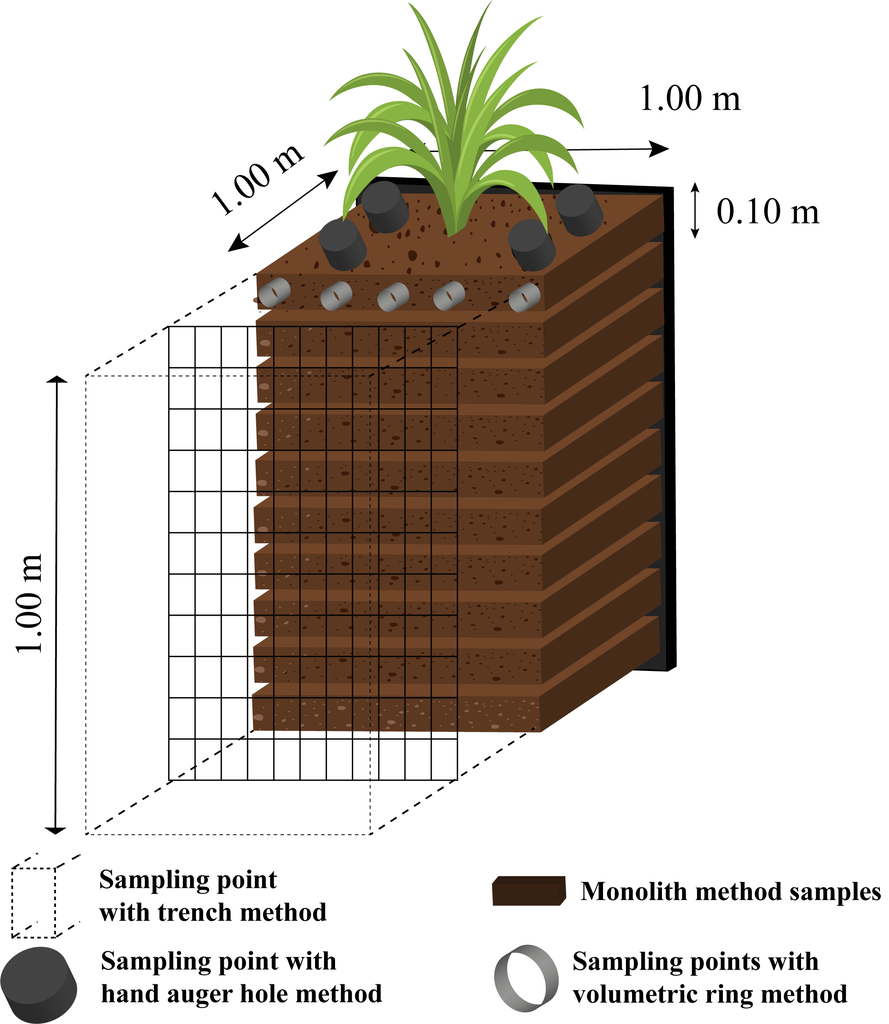

**Índices compostos**

| Índice | Aplicação |
| --- | --- |
| **IQA** (CETESB/ANA) | Qualidade da água bruta |
| **Índice de Estado Trófico** | Lagos e reservatórios |
| **IQS** (qualidade do solo) | Aula seguinte |
| **Fragilidade Ambiental (Ross)** | Suscet. física integrada |
| **Índice Fuzzy de Sustentabilidade** | Sistemas multivariáveis com incerteza |
| **IIC / dPC** | Conectividade da paisagem |

> Cuidado com **agregação cega**: índices compõem variáveis heterogêneas com ponderação que **deve ser justificada** (literatura, AHP, especialistas).

## Diagnóstico e monitoramento

### Linha de base e série temporal

- **Linha de base**: caracterização do estado de referência.
- **Monitoramento**: aferição sistemática em intervalos definidos.
- **Análise de tendência**: Mann-Kendall, Theil-Sen, mudanças de regime (BFAST).
- **Limiares**: alerta, ação, emergência (definidos por norma ou referência histórica).

### Ciclo da gestão adaptativa

Medir → Avaliar → Decidir → Intervir → Medir novamente. Os indicadores são o **núcleo informacional** desse ciclo.

**Exercício orientado**

Para a sub-bacia escolhida no semestre:

1. Selecione 8 indicadores cobrindo os 3 meios.
2. Justifique cada escolha pelos filtros de Fidalgo (2003).
3. Indique fonte de dados, frequência e custo estimado.
4. Proponha 3 limiares de ação (alerta / ação / emergência).

# Referências

## Bibliografia da aula

- FIDALGO, E. C. C. **Critérios para a análise de métodos e indicadores ambientais usados na etapa de diagnóstico de planejamentos ambientais**. Rio de Janeiro: Embrapa Solos, 2003.
- IBGE. **Análise ambiental e gestão do território**: contribuições teórico-metodológicas. Rio de Janeiro: IBGE, 2018.
- OECD. **Environmental indicators**: development, measurement and use. Paris: OECD, 2003.